# Kellar School SOL Analysis 2019

Andrew McCartney

6/4/2019

# Introduction

FAIRFAX, Virginia – This is a living document containing a series of analysis meant to address program-wide, big-picture questions evaluating and assessing the Kellar School’s academic efficacy. As additional research questions are identified or as methodological considerations become more developed, additional notes and analysis will be added. In general, the document should be read tentatively with the following caveats: (1) data requirements–for many of these analytic strategies are much larger or much cleaner than what we possess. (2) Time–the data represent a snapshot in time that may not capture factors that are relevant at other times during the school year. (3) History–For example, events that occur in a student’s life, a school community, or in the wider world can have effects on student outcomes that will never be captured herein. A good example would be a change in mediction regimen or teacher staffing. (4) Maturation–theoretically, student should be improving at all times regardless of what is done with them. Additionally, irrespective of how good a teacher is, the “teacher effect” is about d = 0.30 effect size, meaning that many of the differences we see here are small relative to the size of other educational effects.

## The SOL scores in general

SOLs scores are given as scaled scores, with a possible range of 200 to 600 points. A passing score is 400, but additional cut scores exist: students earning a 375 are available for an expedited re-take and, if they have a documented learning disability, are eligible for credit accommodations (to wit, a Locally Awarded Verified Credit). At lower levels and of the scaled score, an individual correct answer may represent 5-10 scaled score points. At the range near a passing score, each correct answer is 4 points. Above scores of 550 or so, the correspondence between number of correct answers and the scaled score is looser–it is possible to miss one or two questions and still earn a 600. Additionally, approximately 10-15 of the questions each student answers are not counted toward a scaled score, as they are items that are being tested for future use on SOLs, provided they are properly validated.

### SOL scores at Kellar

```r
dat %>%
  filter(!is.na(scaled_score)) %>%
  # select(scaled_score) %>%
  ggvis( ~scaled_score) %>%
  layer_histograms(fill := sample(inova, 1),
                    width = input_slider(1, 20, value = 8)) %>%
  add_title(title = "Histogram of SOL Scaled Scores",
          x_lab= "SOL Scaled Scores")
```

[output not shown]

### SOL Scores by Core Subject

```r
dat %>%
  dplyr::select(scaled_score, core) %>%
  # select_if(is_extant) %>%
  # select_if(is_numeric) %>%
  psych::describeBy(group = dat$core, fast = TRUE)
```

```
##
##  Descriptive statistics by group
## group: eng
##              vars  n   mean    sd min  max range   se
## scaled_score    1 81 409.59 70.98 260  600   340 7.89
## core            2 81    NaN    NA Inf -Inf  -Inf   NA
## --------------------------------------------------------
## group: histss
##              vars  n   mean    sd min  max range   se
## scaled_score    1 82 400.84 42.02 306  565   259 4.64
## core            2 82    NaN    NA Inf -Inf  -Inf   NA
## --------------------------------------------------------
## group: math
##              vars   n   mean    sd min  max range   se
## scaled_score    1 103 361.14 36.31 205  457   252 3.58
## core            2 103    NaN    NA Inf -Inf  -Inf   NA
## --------------------------------------------------------
## group: sci
##              vars  n   mean    sd min  max range   se
## scaled_score    1 65 399.68 36.09 324  501   177 4.48
## core            2 65    NaN    NA Inf -Inf  -Inf   NA
```

## FSIQ scores in this dataset

FSIQ (Full Scale Intelligence Quotient, but not really) is intended to be a measure of intelligence among studnets capturing verbal, nonverbal, and quantitative reasoning, among others. Each student who is referred to TKS is required to have a psychological evaluation, but these are not always delivered to TKS in the referral packet. This is the first reason why many FSIQ scores are missing.

The second reason is that responsible psychometricians are often reluctant to report out a Full-Scale IQ when the subcomponents of the IQ assessment are widely dispersed. For example, if a student has a very low verbal intelligence (say, 70) and a very high nonverbal intelligence relative to that, (say, 115), the FSIQ begins to lack validity as a measure of *general* intelligence. Many of our students therefore have no FSIQ for this reason.

Finally, there is not one measure of IQ being employed in the evaluation of our students. We have scores from the KTEA, the Wechsler, and other IQ tests. These scores do not always, and aren’t necessarily intended to, agree with one another. There should be a correlation, but its strength will not be as high as one might expect. However, to include the type of IQ test as a variable adds more noise to our data than it eliminates–we are using FSIQ as a control covariate and do not need precise scores for this reason.

### FSIQ at Kellar

```r
dat %>%
  filter(!is.na(fsiq)) %>%
  # select(scaled_score) %>%
  ggvis( ~fsiq) %>%
  layer_histograms(fill := sample(inova, 1),
                    width = input_slider(1, 20, value = 6)) %>%
  add_title(title = "Histogram of SOL Scaled Scores",
          x_lab= "SOL Scaled Scores")
```

[output not shown]

## Methodological Note:

**On Clustering:** When testing the effectiveness of a treatment in many fields such as Education or Mental Health, one needs to consider the effect of “clustering” or “nesting” on the outcomes of individual students or patients. What this means is that individual teachers and therapists, who may have 30-150 or more subjects in their treatment group, may have unaccounted-for effects on the outcomes of individual students or patients. For example, if Teacher A and Teacher B both are in the treatment group, but they implement the treatment differently from one another, then Teacher A’s students effectively got a *different treatment* from Teacher B’s students. This effect can bias the results. In education research, we find that about 15% of a student’s score-variability comes from what teacher they have. About 85% comes from individual student-level characteristics. In our data set, we have SOL scores that are clustered within-student, students that are clustered within-teacher (though this changes) and students that are clustered within-subject.

Value-Added models are a popular way of assessing teacher efficacy in public school systems, in part because it allows one to account for clustering and find the pure ‘teacher effect’ for each individual teacher in a district each year, year-over-year. This is logistically impossible at TKS. However, with a sufficiently-large data set of student scores, we can *start* to address the clustering problem in a few different ways.

These analyses will use two different techniques to address clustering. At the student level, we will use linear-mixed-effects (A.K.A. Multilevel Modeling, A.K.A. Hierarchical Linear Modeling). For teacher-level clustering, we will use Fixed Effects (in its econometric sense) to determine the effect of each teacher.

# Question 1: SOL Scores Over Time

## In the last three to four years, have SOL scores changed on average?

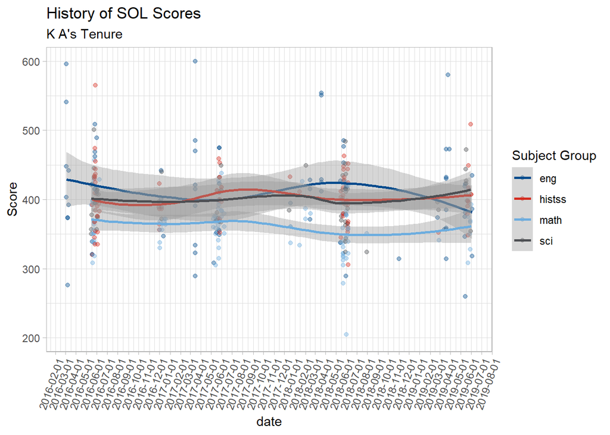

```r
dat  %>%
ggplot(aes(x = date, y = scaled_score, color = core))  +
# geom_jitter(alpha = 0.4, width = 0.25, height = 0.25)  +
geom_point(alpha = 0.4)+
geom_smooth() +
scale_color_inova() +
theme_light() +
labs(title= "History of SOL Scores",
     subtitle = "K A's Tenure",
     y = "Score",
     x = "date",
     color = "Subject Group"
    ) +
scale_y_continuous(limits = c(200, 600)) +
scale_x_date(date_breaks = "1 month") +
theme(axis.text.x = element_text(angle = 70, hjust = 1))
```

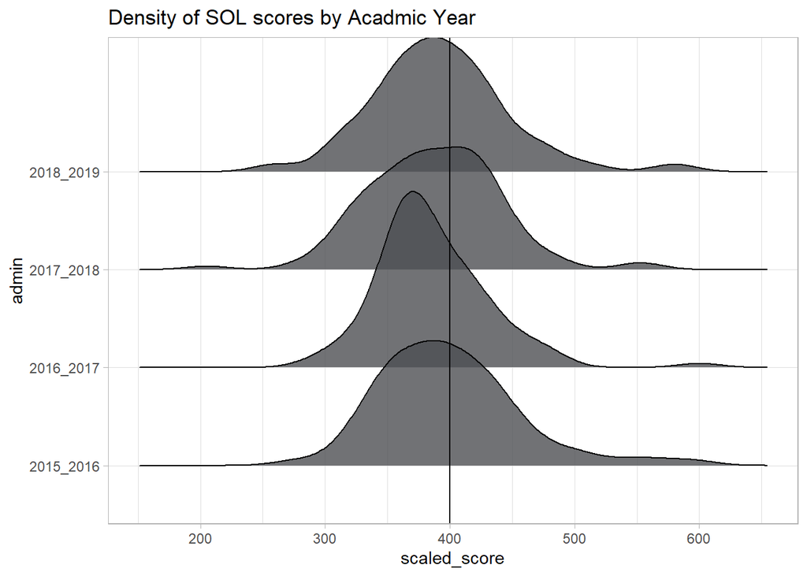

```r
 dat %>%
   ggplot(aes(x = scaled_score, y = admin, fill = admin)) +
   ggridges::geom_density_ridges(alpha = 0.8, fill = sample(inovapal, 1)) +
   labs(title ="Density of SOL scores by Acadmic Year")+
   theme_light() +
   scale_fill_manual(values = inovapal) +
   scale_color_manual(values = inovapal) +
   geom_vline(xintercept = 400)
```

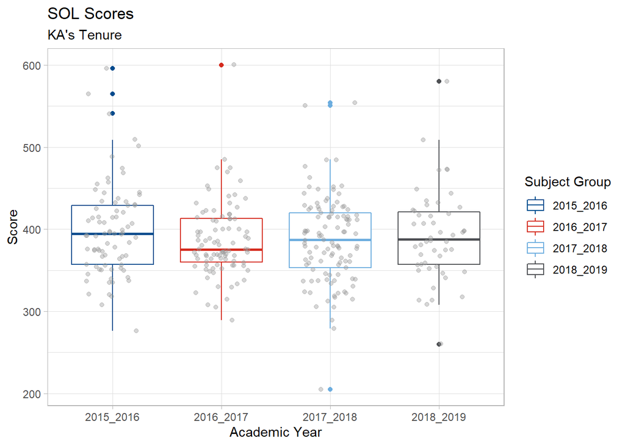

```r
dat  %>%
ggplot(aes(x = admin, y = scaled_score, color = admin))  +
geom_boxplot() +
scale_color_inova() +
geom_jitter(alpha = 0.4, width = 0.25, color = "#999999") +
theme_light() +
labs(title= "SOL Scores",
     subtitle = "KA's Tenure",
     y = "Score",
     x = "Academic Year",
     color = "Subject Group"
    )
```

## Subquestion: SOL scores by Subject

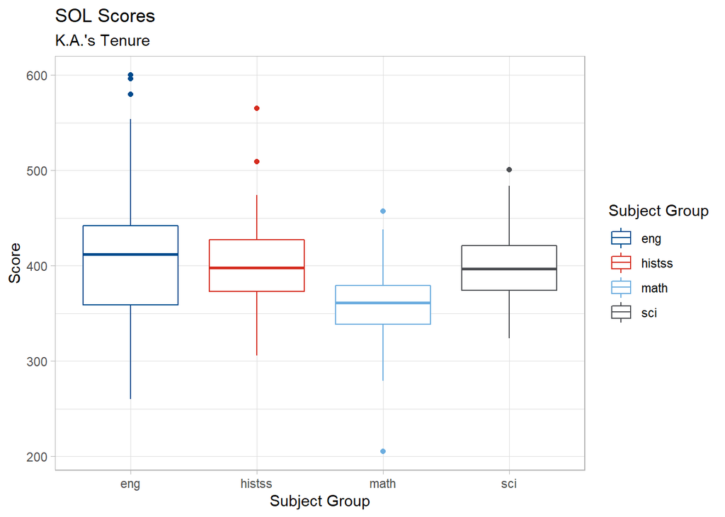

```r
 dat  %>%
 ggplot(aes(x = core, y = scaled_score, color = core))  +
 geom_boxplot() +
 scale_color_inova() +
 theme_light() +
 labs(title= "SOL Scores",
      subtitle = "K.A.'s Tenure",
      y = "Score",
      x = "Subject Group",
      color = "Subject Group"
     )
```

```r
anova(lm(scaled_score ~ core, data = dat))
```

|  | Df | Sum Sq | Mean Sq | F value | Pr(>F) |
| --- | --- | --- | --- | --- | --- |
| core | 3 | 132578.6 | 44192.851 | 18.91781 | 2.446852e-11 |
| Residuals | 327 | 763886.8 | 2336.045 | NA | NA |

```r
car::leveneTest(scaled_score ~ core, data = dat)
```

|  | Df | F value | Pr(>F) |
| --- | --- | --- | --- |
| group | 3 | 13.58864 | 2.240883e-08 |
|  | 327 | NA | NA |

```r
# need heteroskedasticity-robust standard errors here.
```

## SOL Scores by Time and Subject

```r
dat   %>%
# heteroskedasticity-robust because of 2015-2016 SY
rlm(scaled_score ~ admin*core, data = ., psi = psi.bisquare)  %>%
tab_model()
```

|  | scaled score |  |  |
| --- | --- | --- | --- |
| Predictors | Estimates | CI | p |
| (Intercept) | 418.41 | 399.24 – 437.58 | **<0.001** |
| admin2016_2017 | -30.06 | -56.23 – -3.88 | **0.024** |
| admin2017_2018 | 4.30 | -22.82 – 31.41 | 0.756 |
| admin2018_2019 | -36.14 | -62.60 – -9.67 | **0.007** |
| corehistss | -27.02 | -52.46 – -1.59 | **0.037** |
| coremath | -48.76 | -75.88 – -21.65 | **<0.001** |
| coresci | -20.28 | -48.19 – 7.62 | 0.154 |
| admin2016_2017:corehistss | 41.53 | 4.75 – 78.30 | **0.027** |
| admin2017_2018:corehistss | 5.12 | -30.43 – 40.68 | 0.778 |
| admin2018_2019:corehistss | 43.83 | 3.65 – 84.01 | **0.033** |
| admin2016_2017:coremath | 25.95 | -9.21 – 61.12 | 0.148 |
| admin2017_2018:coremath | -20.14 | -56.08 – 15.80 | 0.272 |
| admin2018_2019:coremath | 27.16 | -15.78 – 70.10 | 0.215 |
| admin2016_2017:coresci | 30.19 | -9.75 – 70.12 | 0.138 |
| admin2017_2018:coresci | -8.03 | -45.78 – 29.73 | 0.677 |
| admin2018_2019:coresci | 49.47 | 6.03 – 92.92 | **0.026** |
| Observations | 331 |  |  |

```r
# dummy variables generated for your own individual use:
dat   %>%
mutate(yearfirst = if_else(admin == "2015_2016", 1, 0))  %>%
mutate(yearsecond = if_else(admin == "2016_2017", 1, 0))  %>%
mutate(yearthird = if_else(admin == "2017_2018", 1, 0))  %>%
mutate(yearfourth = if_else(admin == "2018_2019", 1, 0))  %>%
mutate(mathematics = if_else(core == "math", 1,0))  %>%
mutate(english = if_else(core =="eng",1,0))  %>%
mutate(science = if_else(core =="sci", 1,0))  %>%
mutate(history = if_else(core == "histss", 1,0))  %>%
rlm(scaled_score ~ yearsecond + yearthird + yearfourth + mathematics + english + science +
    yearsecond*mathematics + yearsecond*english + yearsecond*science +
    yearthird*mathematics + yearthird*english + yearthird*science +
    yearfourth*mathematics + yearfourth*english + yearfourth*science,
    data = ., psi = psi.bisquare)  %>%
tab_model()
```

|  | scaled score |  |  |
| --- | --- | --- | --- |
| Predictors | Estimates | CI | p |
| (Intercept) | 391.39 | 374.67 – 408.10 | **<0.001** |
| yearsecond | 11.47 | -14.37 – 37.30 | 0.384 |
| yearthird | 9.42 | -13.58 – 32.42 | 0.422 |
| yearfourth | 7.70 | -22.54 – 37.94 | 0.618 |
| mathematics | -21.74 | -47.18 – 3.70 | 0.094 |
| english | 27.02 | 1.59 – 52.46 | **0.037** |
| science | 6.74 | -19.53 – 33.01 | 0.615 |
| yearsecond:mathematics | -15.57 | -50.49 – 19.34 | 0.382 |
| yearsecond:english | -41.53 | -78.30 – -4.75 | **0.027** |
| yearsecond:science | -11.34 | -51.05 – 28.38 | 0.576 |
| yearthird:mathematics | -25.27 | -58.21 – 7.68 | 0.133 |
| yearthird:english | -5.12 | -40.68 – 30.43 | 0.778 |
| yearthird:science | -13.15 | -48.07 – 21.77 | 0.460 |
| yearfourth:mathematics | -16.68 | -62.04 – 28.69 | 0.471 |
| yearfourth:english | -43.83 | -84.01 – -3.65 | **0.033** |
| yearfourth:science | 5.64 | -40.20 – 51.48 | 0.809 |
| Observations | 331 |  |  |

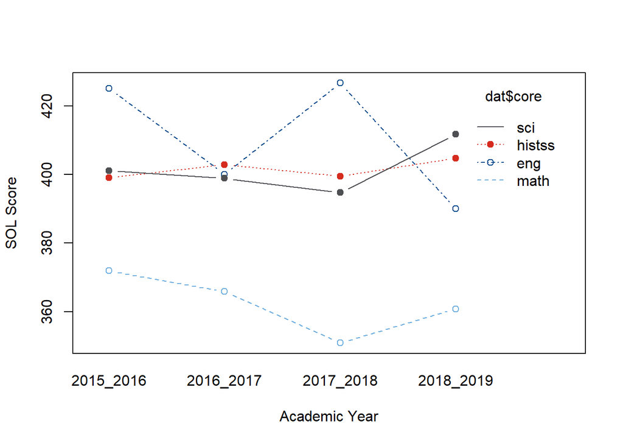

```r
# Two way anova interaction.
# inova ANOVA!
interaction.plot(x.factor = dat$admin, trace.factor = dat$core,
                 response = dat$scaled_score, fun = mean,
                 type = "b", legend = TRUE,
                 xlab = "Academic Year", ylab="SOL Score",
                 pch=c(1,19),
                 col = c("#004b8d", "#d52b1e", "#6caddf", "#4d4f53"))
```

# Question 2: FSIQ Over Time

Having considered whether the SOL scores have changed over time, we might wonder what the effect is of the nature of our student population over time on our SOL pass rate. For example, we have all noted that ‘types’ of students tend to get referred in clusters and that this is a feedback loop wherein the Kellar School gets a reputation for doing well with a certain type of student and gets more of them. This analysis does not exclude SAILS, so to the extent that they take SOLs you might consider how the growth of that program affects the school’s average IQ.

To address this question, we would do best to match each FSIQ to a student’s start- and end-date and then create a running average for each day of the school year. However, start and end date data are difficult (but not impossible) to collect for ~300 datapoints; therefore we will instead map FSIQ scores to SOL administrations to determine the change over time:

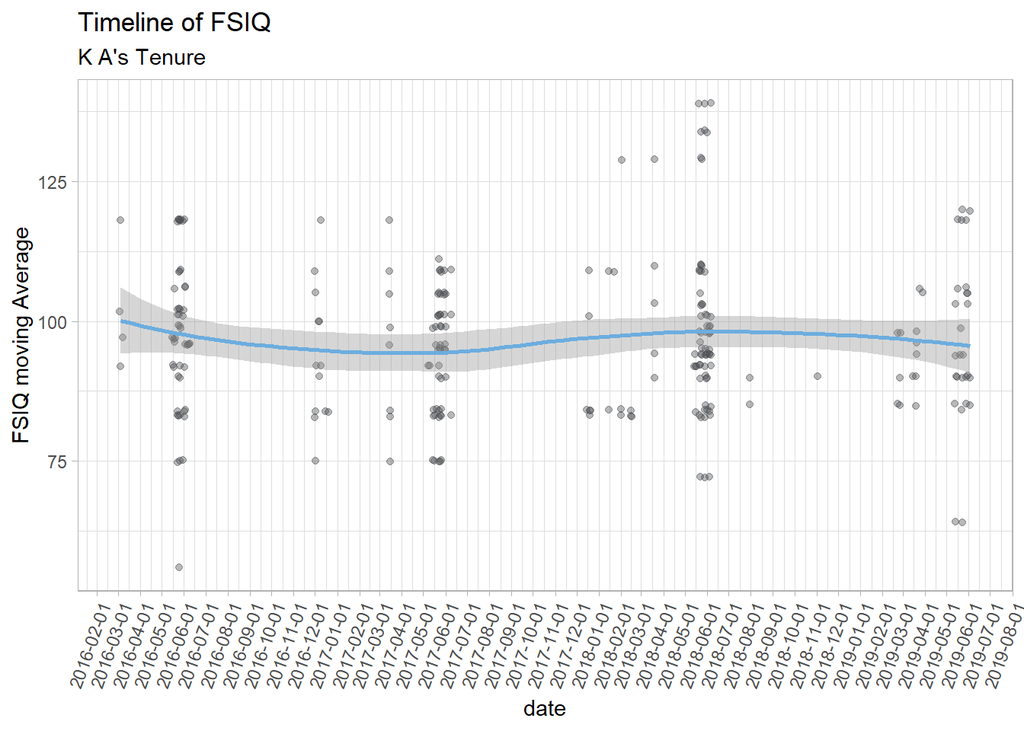

```r
dat  %>%
ggplot(aes(x = date, y = fsiq))  +
geom_jitter(color = "#4d4f53", alpha = 0.4, width = 0.25, height = 0.25)  +
geom_smooth( color ="#6caddf") +
scale_color_inova() +
theme_light() +
labs(title= "Timeline of FSIQ",
     subtitle = "K A's Tenure",
     y = "FSIQ moving Average",
     x = "date",
     color = "Subject Group"
    ) +
scale_y_continuous() +
scale_x_date(date_breaks = "1 month") +
theme(axis.text.x = element_text(angle = 70, hjust = 1))
```

We find the line is essentially flat. It does dip in the 2016-2017 school year (corresponding to a dip in SOL scores at the same time) but in general the peaks and valleys, such as they are, do not step outside the standard error bar, indicating that we can’t conclude the line *isn’t* flat.

I would conclude that despite a perceived increase in student ability in so-called Kellar Proper, there may be mitigating school-wide effects created by including SAILS in SOL scores, as SAILS students represent some (but not all) of the lowest-IQ students at TKS. In all, I wouldn’t say that we have had any meaningful change in student ability.